```python
import IPython.core.display as di

# This line will hide code by default when the notebook is exported as HTML
di.display_html('<script>jQuery(function() {if (jQuery("body.notebook_app").length == 0) { jQuery(".input_area").toggle(); jQuery(".prompt").toggle();}});</script>', raw=True)
```

# Udacity Data Analyst NanoDegree Identifying Fraud from Enron Email

## Enron Submission Free-Response Questions and Answers

#### 1. Summarize for us the goal of this project and how machine learning is useful in trying to accomplish it. As part of your answer, give some background on the dataset and how it can be used to answer the project question. Were there any outliers in the data when you got it, and how did you handle those? [relevant rubric items: “data exploration”, “outlier investigation”]

This project attempts to identify someone being a suspect of Enron fraud conspiracy by looking at given dataset. We call the suspects Person of Interest (POI). The dataset contains insider pays to all Enron executives as well as emails sent through their company accounts, and their POI status. We will use machine learning to build the prediction model for identifying the likeness of someone with a particular pattern of being a POI or non-POI.

The dataset in this project there are 146 individuals which only 18 are persons of interest and contain 20 features and 1 taget.

Through exploratory data analysis the features show various missing with NaN values, except 'poi' Finally I was identify 3 records as outliers should be removed from dataset • TOTAL: This was an extreme outlier for most numerical features, as it was likely a spreadsheet artifact. • THE TRAVEL AGENCY IN THE PARK: This record did not represent an individual. • LOCKHART EUGENE E: This record contained all NaN value.

#### 2. What features did you end up using in your POI identifier, and what selection process did you use to pick them? Did you have to do any scaling? Why or why not? As part of the assignment, you should attempt to engineer your own feature that does not come ready-made in the dataset -- explain what feature you tried to make, and the rationale behind it. (You do not necessarily have to use it in the final analysis, only engineer and test it.) In your feature selection step, if you used an algorithm like a decision tree, please also give the feature importances of the features that you use, and if you used an automated feature selection function like SelectKBest, please report the feature scores and reasons for your choice of parameter values. [relevant rubric items: “create new features”, “properly scale features”, “intelligently select feature”]

The feature engineering was done by fill all missing value features with median value. Next I create new featue based on financial data for net_earning for each individuals. For the email features were replaced with normalizing by dividing by total of sent or recieved by person, It's important to normalize of email counts since sometime person who may send or recieve more email. Finally feature engineering done with create 5 new features as:

```
• net_earnings
• poi_sending_ratio
• poi_receive_ratio
• poi_overall_ratio
• shared_receipt_ratio
```

For feature scaling, because large value in the features, I used RobustScaler to smoothen the value of financeial features when perform pipeline for GridSearchCV to proceed base parameter of classifiers model.

Features selection done by SelectKBes, the score of feature was:

[output not shown]

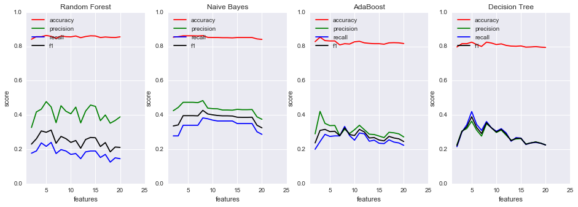

```python
from IPython.display import Image
Image(filename='feature_selection.png')
```

From the plot result show K = 5 and 8 yield high score, so then I decided to validated with final algorithm for pickup final features, the result was:

| K | Accuracy | Precision | Recall | F1 |
| --- | --- | --- | --- | --- |
| 5 | 0.97733 | 1.00000 | 0.83000 | 0.90710 |
| 8 | 0.98407 | 1.00000 | 0.88050 | 0.93645 |

Then I decided to selectd K = 8, then final feature importances of the model were:

```
• poi
• exercised_stock_options
• total_stock_value
• net_earnings
• bonus
• poi_receive_ratio
• poi_overall_ratio
• salary
• deferred_income
```

#### 3. What algorithm did you end up using? What other one(s) did you try? How did model performance differ between algorithms? [relevant rubric item: “pick an algorithm”]

I ended up with RandomForest algorithm, as implemented in sklearn. I also tried with other four different classification algorithms were as GaussianNB, DecisionTree, AdaBoost, and Support Vector Machine with RBF . Algorithm selection perform by following steps:

```
1. Ran SelectKBest with serveral classifiers to find best set features.
3. Run GridSearchCV to optimize the best parameter then choose the algorithm
a. tune algorithm using the additional parameter set base on scikit-learn document.
```

After tuning the parameter then using tester.py to evaluate performance of model:

#### 4. What does it mean to tune the parameters of an algorithm, and what can happen if you don’t do this well? How did you tune the parameters of your particular algorithm? (Some algorithms do not have parameters that you need to tune -- if this is the case for the one you picked, identify and briefly explain how you would have done it for the model that was not your final choice or a different model that does utilize parameter tuning, e.g. a decision tree classifier). [relevant rubric item: “tune the algorithm”]

Each algorithms have a varity of parameters that can take on several values to yield the performance of the algorithm. Parameter tuning means trying serveral different values for each parameter set to optimize the best performance of the algorithm. If parameter tuning is not done well, the best performance of the algorithm will be missed.

In this project I have start to get optimum start parameter for each algorithm with GridSearchCV then after get optimum parameter, next I manual adjust parameter to meet the requirement.

The result from GridSearchCV was: Decision Tree min_samples_leaf = 6 min_samples_split = 10

```
Naive Bayes
    selectkbest__k = 7

SVM
    gamma = 0.001
    selectkbest__k = 3
    C = 100

AdaBoost
    algorithm = SAMME
    n_estimators = 16
    learning_rate = 0.6

Random Forest
    min_samples_split = 11
    n_estimators = 15
    max_features = auto

Base validate score
           DecisionTree  NaiveBayes SVM       AdaBoost  Random Forest
precision  0.303511      0.482596   0.390497  0.447699  0.485884
recall     0.250556      0.248333   0.098333  0.239444  0.161111
```

Finally I select RandomForset for final model and tune more parameter set as below.

```
RandomForestClassifier(bootstrap=True,
                       class_weight=None,
                       criterion='entropy',
                       max_depth=None,
                       max_features='sqrt',
                       max_leaf_nodes=None,
                       min_samples_leaf=1,
                       min_samples_split=2,
                       min_weight_fraction_leaf=0.0,
                       n_estimators=35,
                       n_jobs=1,
                       oob_score=False,
                       random_state=142,
                       verbose=0,
                       warm_start=True)
Accuracy: 0.98407   Precision: 1.00000  Recall: 0.88050 F1: 0.93645 F2: 0.90206
Total predictions: 15000
True positives: 1761
False positives:    0
False negatives:  239
True negatives: 13000
```

#### 5. What is validation, and what’s a classic mistake you can make if you do it wrong? How did you validate your analysis? [relevant rubric item: “validation strategy”]

Validation is the process to evaluate the algorithm performance with datset splitting into training and testing sets. We'll use the training set to train our algorithm, after that we'll evaluate the performance of our model with the testing set, that has not seen previously. By this process we can validated the performance of our algorithm to generalize its conclusions for the new data. If we do not validat our algorithm previously then our model may be very likely to overfiting on the new dataset that it has not observations previously.

With small dataset (18 POI and 125 non-POI after removing outliers), I used StratifiedShuffleSplit to split 50% of data into training set and put remaing 50% into testing sets to avoid overfitting and robust result.

Then to validation final algorithm, I used test_classifier function in tester.py for testing the algorithm to ensure that each data point got the chance in testing process, so that validation results along dataset don’t depend on any specific pattern or characteristics of the dataset.

#### 6. Give at least 2 evaluation metrics and your average performance for each of them. Explain an interpretation of your metrics that says something human-understandable about your algorithm’s performance. [relevant rubric item: “usage of evaluation metrics”]

I have used 4 evaluation metrics accuracy, precision, recall, and the F1-score. These metrics are based on predictive comparing of POI/non-POI to the actual.

Accuracy is the number of correct answers the model produced.

Precision is the number of times positively identifies a data point (True positive) divided by the total number of positive identifications (regardless of whether they were correct). High number of precision reflact POIs identified by the algorithm tended to be correct, while a low number means there were more failure to identifies non-POIs as POIs.

Recall is the number of true positives divided by the sum of the true positives and the number of incorrectly negatively identified a data point (false negative). Higher recall reflacted the algorithm do a good job of identifying the POIs in the test set, while lower recal reflact ther incorrectly labeling a POI as a non-POI.

F1 score is average weighted of precision and recall, calculated by multiplying the product of the recall and precision by two, then dividing with sum of the precision and recall.

The average performance my final algorithms was :

```
RandomForestClassifier
Accuracy: 0.98407
Precision: 1.00000
Recall: 0.88050
F1: 0.93645
F2: 0.90206

Total predictions: 15000
True positives: 1761
False positives:    0
False negatives:  239
True negatives: 13000
```

Base on result the algorithm the prediction of POI or non-POI when the person was POI or non-POI had accuracy as 98%, and the model could predicted people to be POI correctly as 100% of times. Also the model can identify the POI’s label in the dataset by 88% of them.